# Major Storms and Weather Events Which Are Most Harmful to US Population Health and Economies

## Synopsis

In this report, we examine the data available for weather storm events in the US (1950 - 2011) and determine which events have caused the most harm, so that someone, who might be responsible for preparing for severe weather events, might have an idea of how to prioritize resources for different types of events. We first see which events have caused the most harm to population health, by looking at fatalities and injuries. The event type which caused the most harm physically was definitely the tornado, which caused almost one hundred thousand health incidents (fatalities + injuries). The other 9 most-harmful types each caused less than ten thousand health incidents. They include excessive heat, TSTM (thunderstorm) wind, flood, and lightning. The event type which caused the most harm financially (and therefore, economically) was flooding, which has a total damage amount of over one hundred fifty billion dollars ($1.503 x 10<sup>11).</sup> The second-most harmful was hurricane/typhoon with about half the dollar amount ($7.191 x 10<sup>10).</sup> Other significant types, for economic damage, include tornado, storm surge, and hail.

## Introduction

From the project info:

“Storms and other severe weather events can cause both public health and economic problems for communities and municipalities. Many severe events can result in fatalities, injuries, and property damage, and preventing such outcomes to the extent possible is a key concern.

This project involves exploring the U.S. National Oceanic and Atmospheric Administration's (NOAA) storm database. This database tracks characteristics of major storms and weather events in the United States, including

- when and where they occur
- estimates of any fatalities, injuries, and property damage.”

This assignment will look at this database to address the following questions:

- Across the United States, which types of events (as indicated in the EVTYPE variable) are most harmful with respect to population health?
- Across the United States, which types of events have the greatest economic consequences?

## About the Data

The data for this assignment come in the form of a comma-separated-value file compressed via the bzip2 algorithm to reduce its size. You can download the file from the course web site.

The events in the database start in the year 1950 and end in November 2011. In the earlier years of the database there are generally fewer events recorded, most likely due to a lack of good records. More recent years should be considered more complete.

## Data Processing

### Loading the Data

To load the libraries that will be used:

```r
library(plyr)
library(dplyr)
library(grDevices)
library(RColorBrewer)
```

To load the data file:

```r
storm_data <- read.csv("repdata-data-StormData.csv.bz2", na.strings="")
```

To see the number of observations:

```r
print(nrow(storm_data))
```

```
## [1] 902297
```

To format the columns' names:

```r
cnames <- gsub("_", ".", tolower(names(storm_data)))
names(storm_data) <- make.names(cnames)  ## Ensure names are properly formatted
print(names(storm_data))
```

```
##  [1] "state.."    "bgn.date"   "bgn.time"   "time.zone"  "county"
##  [6] "countyname" "state"      "evtype"     "bgn.range"  "bgn.azi"
## [11] "bgn.locati" "end.date"   "end.time"   "county.end" "countyendn"
## [16] "end.range"  "end.azi"    "end.locati" "length"     "width"
## [21] "f"          "mag"        "fatalities" "injuries"   "propdmg"
## [26] "propdmgexp" "cropdmg"    "cropdmgexp" "wfo"        "stateoffic"
## [31] "zonenames"  "latitude"   "longitude"  "latitude.e" "longitude."
## [36] "remarks"    "refnum"
```

Now, to select the columns that will be needed for the analysis: evtype, fatalities, injuries, propdmg, propdmgexp, cropdmg, and cropdmgexp.

```r
storm_data <- select(storm_data, evtype, injuries, fatalities, propdmg, propdmgexp, cropdmg, cropdmgexp)
print(summary(storm_data))
```

```
##                evtype          injuries           fatalities
##  HAIL             :288661   Min.   :   0.0000   Min.   :  0.0000
##  TSTM WIND        :219940   1st Qu.:   0.0000   1st Qu.:  0.0000
##  THUNDERSTORM WIND: 82563   Median :   0.0000   Median :  0.0000
##  TORNADO          : 60652   Mean   :   0.1557   Mean   :  0.0168
##  FLASH FLOOD      : 54277   3rd Qu.:   0.0000   3rd Qu.:  0.0000
##  FLOOD            : 25326   Max.   :1700.0000   Max.   :583.0000
##  (Other)          :170878
##     propdmg          propdmgexp        cropdmg          cropdmgexp
##  Min.   :   0.00   K      :424665   Min.   :  0.000   K      :281832
##  1st Qu.:   0.00   M      : 11330   1st Qu.:  0.000   M      :  1994
##  Median :   0.00   0      :   216   Median :  0.000   k      :    21
##  Mean   :  12.06   B      :    40   Mean   :  1.527   0      :    19
##  3rd Qu.:   0.50   5      :    28   3rd Qu.:  0.000   B      :     9
##  Max.   :5000.00   (Other):    84   Max.   :990.000   (Other):     9
##                    NA's   :465934                     NA's   :618413
```

```r
print(sapply(storm_data, class))
```

```
##     evtype   injuries fatalities    propdmg propdmgexp    cropdmg
##   "factor"  "numeric"  "numeric"  "numeric"   "factor"  "numeric"
## cropdmgexp
##   "factor"
```

To work with the property damage values accurately, we need to combine the propdmg values with their corresponding exponent values. We also need to do the same with the cropdmg values.

From P12 of the National Weather Service Storm Data Documentation: “Estimates should be rounded to three significant digits, followed by an alphabetical character signifying the magnitude of the number, i.e., 1.55B for $1,550,000,000. Alphabetical characters used to signify magnitude include

- “K” for thousands
- “M” for millions
- “B” for billions.”

To see what values for the exponents that we need to deal with:

```r
print(levels(storm_data$propdmgexp))
```

```
##  [1] "-" "?" "+" "0" "1" "2" "3" "4" "5" "6" "7" "8" "B" "h" "H" "K" "m"
## [18] "M"
```

```r
print(levels(storm_data$cropdmgexp))
```

```
## [1] "?" "0" "2" "B" "k" "K" "m" "M"
```

The numbers must correspond to powers of ten. 2 means 10<sup>2,</sup> etc.

It isn't clear what the values “-” and “+” mean exactly, so we'll see if the number of observations with - or + as values for propdmgexp is significant:

```r
check <- filter(storm_data, propdmgexp == "-" | propdmgexp == "+")
print(check)
```

```
##                evtype injuries fatalities propdmg propdmgexp cropdmg
## 1    BREAKUP FLOODING        0          0      20          +       0
## 2           HIGH WIND        0          0      20          +       0
## 3 FLOODING/HEAVY RAIN        0          0       2          +       0
## 4          HIGH WINDS        0          0      15          +       0
## 5             TORNADO        0          0      60          +       0
## 6           HIGH WIND        0          2      15          -       0
##   cropdmgexp
## 1       <NA>
## 2       <NA>
## 3       <NA>
## 4       <NA>
## 5       <NA>
## 6       <NA>
```

```r
print(nrow(check))
```

```
## [1] 6
```

```r
sprintf("Percentage of observations = %4f%%", nrow(check)/nrow(storm_data) * 100 )
```

```
## [1] "Percentage of observations = 0.000665%"
```

Since it is such a small number, we won't deal with those.

Now, to reevaluate the values of propdmg which have corresponding propdmgexp values of letters or integers:

```r
storm_data <- mutate(storm_data, propdmg = ifelse(propdmgexp=="2" | propdmgexp=="H" | propdmgexp=="h",
                                                  propdmg * 100, propdmg))
storm_data <- mutate(storm_data, propdmg = ifelse(propdmgexp=="3" | propdmgexp=="K" | propdmgexp=="k",
                                                  propdmg * 1000, propdmg))
storm_data <- mutate(storm_data, propdmg = ifelse(propdmgexp=="4", propdmg * 10000, propdmg))
storm_data <- mutate(storm_data, propdmg = ifelse(propdmgexp=="5", propdmg * 100000, propdmg))
storm_data <- mutate(storm_data, propdmg = ifelse(propdmgexp=="6" | propdmgexp=="M" | propdmgexp=="m",
                                                  propdmg * 1000000, propdmg))
storm_data <- mutate(storm_data, propdmg = ifelse(propdmgexp=="7", propdmg * 10000000, propdmg))
storm_data <- mutate(storm_data, propdmg = ifelse(propdmgexp=="8", propdmg * 100000000, propdmg))
storm_data <- mutate(storm_data, propdmg = ifelse(propdmgexp=="9" | propdmgexp=="B" | propdmgexp=="b",
                                                  propdmg * 1000000000, propdmg))
```

And next, to reevaluate the values of cropdmg which have corresponding cropdmgexp values of letters or integers:

```r
storm_data <- mutate(storm_data, cropdmg = ifelse(cropdmgexp=="2", cropdmg * 100, cropdmg))
storm_data <- mutate(storm_data, cropdmg = ifelse(cropdmgexp=="K" | cropdmgexp=="k" , cropdmg * 1000, cropdmg))
storm_data <- mutate(storm_data, cropdmg = ifelse(cropdmgexp=="M" | cropdmgexp=="m" , cropdmg * 1000000 , cropdmg))
storm_data <- mutate(storm_data, cropdmg = ifelse(cropdmgexp=="B", cropdmg * 1000000000, cropdmg))
```

Finally, since we will be adding the two damage amounts (propdmg and cropdmg) together later, it would be helpful to change the NA values for propdmg and cropdmg to be 0, so that we will not get something like (100 + NA = NA), since the 100 may be important to keep. So (100 + 0 = 100) would be better.

```r
storm_data <- mutate(storm_data, propdmg = ifelse(is.na(propdmg), 0, propdmg))
storm_data <- mutate(storm_data, cropdmg = ifelse(is.na(cropdmg), 0, cropdmg))
```

## Results

### Determining Which Event Types (the evtype variable) Are Most Marmful with Respect to Population Health:

First, we can look at which events caused the most deaths in the US.

To see how many different possibilities of events we are working with:

```r
num_types <- length(levels(storm_data$evtype))
sprintf("Number of different types of storm events: %s", num_types)
```

```
## [1] "Number of different types of storm events: 985"
```

Now, to sum up the fatalities for each type of event:

```r
fatalities_by_type <- ddply(storm_data, .(evtype), summarize, sum_fatalities=sum(fatalities))
fatalities_by_type <- arrange(fatalities_by_type, desc(sum_fatalities))
print(head(fatalities_by_type))
```

```
##           evtype sum_fatalities
## 1        TORNADO           5633
## 2 EXCESSIVE HEAT           1903
## 3    FLASH FLOOD            978
## 4           HEAT            937
## 5      LIGHTNING            816
## 6      TSTM WIND            504
```

Next, to see which events caused the most injuries in the US: To sum up the injuries for each type of event:

```r
injuries_by_type <- ddply(storm_data, .(evtype), summarize, sum_injuries=sum(injuries))
injuries_by_type <- arrange(injuries_by_type, desc(sum_injuries))
print(head(injuries_by_type))
```

```
##           evtype sum_injuries
## 1        TORNADO        91346
## 2      TSTM WIND         6957
## 3          FLOOD         6789
## 4 EXCESSIVE HEAT         6525
## 5      LIGHTNING         5230
## 6           HEAT         2100
```

To see how the fatalities and injuries come together for a more complete picture of population health:

To combine the two sum variables in the same data frame:

```r
merged <- merge(fatalities_by_type, injuries_by_type, by="evtype", all=TRUE)
merged <- arrange(merged, desc(sum_fatalities))
print(head(merged))
```

```
##           evtype sum_fatalities sum_injuries
## 1        TORNADO           5633        91346
## 2 EXCESSIVE HEAT           1903         6525
## 3    FLASH FLOOD            978         1777
## 4           HEAT            937         2100
## 5      LIGHTNING            816         5230
## 6      TSTM WIND            504         6957
```

To create a variable which combines the fatalities and injuries:

```r
merged <- mutate(merged, total_sum=(sum_fatalities + sum_injuries))
merged <- arrange(merged, desc(total_sum))
print(head(merged))
```

```
##           evtype sum_fatalities sum_injuries total_sum
## 1        TORNADO           5633        91346     96979
## 2 EXCESSIVE HEAT           1903         6525      8428
## 3      TSTM WIND            504         6957      7461
## 4          FLOOD            470         6789      7259
## 5      LIGHTNING            816         5230      6046
## 6           HEAT            937         2100      3037
```

To focus on the most harmful events, the data set is truncated to include the 10 events with the highest total_sum:

```r
most_harmful <- merged[1:10,]
print(most_harmful)
```

```
##               evtype sum_fatalities sum_injuries total_sum
## 1            TORNADO           5633        91346     96979
## 2     EXCESSIVE HEAT           1903         6525      8428
## 3          TSTM WIND            504         6957      7461
## 4              FLOOD            470         6789      7259
## 5          LIGHTNING            816         5230      6046
## 6               HEAT            937         2100      3037
## 7        FLASH FLOOD            978         1777      2755
## 8          ICE STORM             89         1975      2064
## 9  THUNDERSTORM WIND            133         1488      1621
## 10      WINTER STORM            206         1321      1527
```

To plot the most harmful events:

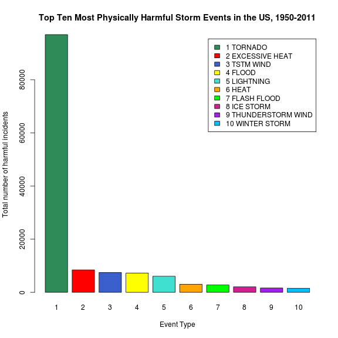

```r
barplot(most_harmful$total_sum,
        names=seq_along(most_harmful$evtype),
        legend.text=as.character(paste(seq_along(most_harmful$evtype), most_harmful$evtype)),
        col=c("seagreen", "red", "royalblue3", "yellow", "turquoise", "orange", "green", "violetred", "purple", "deepskyblue"),
        ylab="Total number of harmful incidents",
        xlab="Event Type",
        main="Top Ten Most Physically Harmful Storm Events in the US, 1950-2011")
```

### Determining Which Event Types Have the Greatest Economic Consequences

Now, to focus on the variables which deal with economic consequences: property damage (propdmg) and crop damage (cropdmg).

To simplify the data frame to include only the needed columns: evtype, propdmg, and cropdmg:

```r
storm_data <- select(storm_data, evtype, propdmg, cropdmg)
print(summary(storm_data))
```

```
##                evtype          propdmg             cropdmg
##  HAIL             :288661   Min.   :0.000e+00   Min.   :0.000e+00
##  TSTM WIND        :219940   1st Qu.:0.000e+00   1st Qu.:0.000e+00
##  THUNDERSTORM WIND: 82563   Median :0.000e+00   Median :0.000e+00
##  TORNADO          : 60652   Mean   :4.746e+05   Mean   :5.442e+04
##  FLASH FLOOD      : 54277   3rd Qu.:5.000e+02   3rd Qu.:0.000e+00
##  FLOOD            : 25326   Max.   :1.150e+11   Max.   :5.000e+09
##  (Other)          :170878
```

```r
print(sapply(storm_data, class))
```

```
##    evtype   propdmg   cropdmg
##  "factor" "numeric" "numeric"
```

To create the variable sum_dmg, which is the sum of each of the observations' propdmg and cropdmg:

```r
storm_data <- mutate(storm_data, sum_dmg = propdmg + cropdmg)
```

Next, to see the sum of the damage by event type:

```r
dmg_by_type <- ddply(storm_data, .(evtype), summarize, total_dmg=sum(sum_dmg))
dmg_by_type <- arrange(dmg_by_type, desc(total_dmg))
top_ten_dmg <- dmg_by_type[1:10,]
print(top_ten_dmg)
```

```
##               evtype    total_dmg
## 1              FLOOD 150319678250
## 2  HURRICANE/TYPHOON  71913712800
## 3            TORNADO  57362333944
## 4        STORM SURGE  43323541000
## 5               HAIL  18761221926
## 6        FLASH FLOOD  18243990872
## 7            DROUGHT  15018672000
## 8          HURRICANE  14610229010
## 9        RIVER FLOOD  10148404500
## 10         ICE STORM   8967041360
```

To plot the events which caused the most economic damage:

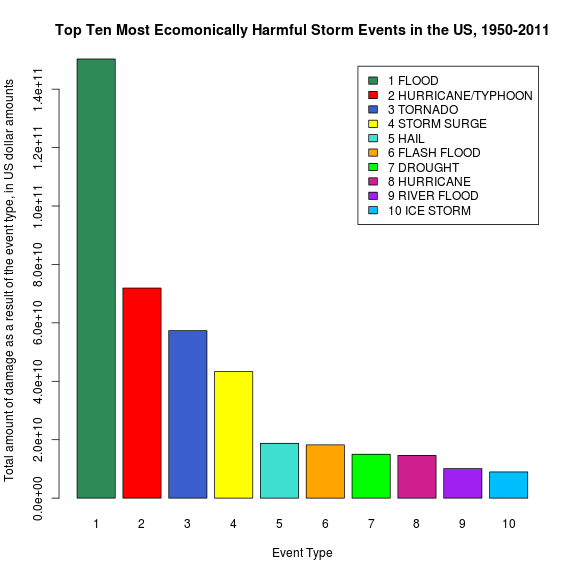

```r
barplot(top_ten_dmg$total_dmg,
        names=seq_along(top_ten_dmg$evtype),
        legend.text=as.character(paste(seq_along(top_ten_dmg$evtype), top_ten_dmg$evtype)),
        col=c("seagreen", "red", "royalblue3", "yellow", "turquoise", "orange", "green", "violetred", "purple", "deepskyblue"),
        ylab="Total amount of damage as a result of the event type, in US dollar amounts",
        xlab="Event Type",
        main="Top Ten Most Ecomonically Harmful Storm Events in the US, 1950-2011")
```